# R语言及其在社会分析中的应用

常象宇

Update 07/10/2018

# 1 R语言基础运算

数据科学的对象主体肯定是数据。在这个大数据时代，任何可以被计算机所记录的都是数据。数据本身是具有数字属性的，那么它们就可以进行基本运算。R语言最初的设计的最基本单元应该是**基础运算**，大家可以把其想象成**计算器**。

[figure not shown]

## 1.1 Basic Operation

| 命令 | 描述 |
| --- | --- |
| `+,-,*,\` | 加, 减, 乘, 除 |
| `^` | 取幂 |
| `%%` | 取余 |
| `round()` | 四舍五入 |
| `floor()` | 向下取整 |
| `ceiling()` | 向上取整 |
| `abs()` | 绝对值 |
| `sqrt()` | 平方根 |
| `log()` | 对数 |
| `exp()` | 指数 |
| `( )` | 改变运算优先级 |

## 1.2 Logical Operation

| 命令 | 描述 |
| --- | --- |
| `&,\|,!` | 与,或,非 |
| `==` | 判断是否相等 |

## 1.3 Assignment Operation

| 命令 | 描述 |
| --- | --- |
| `=` | 单向赋值 |
| `<-` | 双向赋值 |
| `<<-` | 给上一层环境变量赋值 |

## 1.4 Examples

```r
22 %% 6
```

```
## [1] 4
```

```r
floor(22/6)
```

```
## [1] 3
```

```r
sqrt(22/6)
```

```
## [1] 1.914854
```

```r
log(22/6)
```

```
## [1] 1.299283
```

```r
3>4
```

```
## [1] FALSE
```

```r
F == T
```

```
## [1] FALSE
```

- 尝试用4个1计算出24
- `<-` 双向赋值

```r
asg <- 2
```

```r
asg
```

```
## [1] 2
```

```r
3 -> asg
```

```r
asg
```

```
## [1] 3
```

- `=` 单向传值

```r
asg = 1
```

```r
asg
```

```
## [1] 1
```

```r
# 这是错误的写法
1 = asg
```

- `=` 函数参数传值

> `Usage`  
> `matrix(data = NA, nrow = 1, ncol = 1, ...)`

```r
matrix(1:6, 3)
```

```
##      [,1] [,2]
## [1,]    1    4
## [2,]    2    5
## [3,]    3    6
```

`如何生成一个`2 × 3`的矩阵？`

**GOOD**

```r
matrix(1:6, ncol = 3)
```

```
##      [,1] [,2] [,3]
## [1,]    1    3    5
## [2,]    2    4    6
```

**BAD**

```r
matrix(1:6, ncol <- 3)
```

```
##      [,1] [,2]
## [1,]    1    4
## [2,]    2    5
## [3,]    3    6
```

**BAD**函数参数传值

```r
ls() # 显示什么？
```

**BAD**函数参数传值

```r
mean(x = 1:3)
```

```
## [1] 2
```

```r
ls()
```

```
## [1] "asg"  "ncol"
```

```r
mean(x <- 1:3)
```

```
## [1] 2
```

```r
ls()
```

```
## [1] "asg"  "ncol" "x"
```

> **除**函数参数传值**外**, `=` 可被替换为 `<-` , 反之则不然, 如: `system.time(A <- matrix(1:6, 3))`中只能用 `<-`

- `<<-` 表示给上一层环境中的变量赋值
- 建议：进行赋值运算时，使用 `<-` 而非 `=` .

# 2 R中的代码规范

- 阅读**狗熊会**的人才计划推文：代码的规范。
- [Google’s R StyleGuide](https://google.github.io/styleguide/Rguide.xml)

# 3 R中的数据类型

## 3.1 Basic

原子型对象

- 逻辑型：logical
- 字符型：character
- 整数型：integer
- 实数型：numeric (double)
- 复数型：complex

## 3.2 Examples

```r
is.logical(T)
```

```
## [1] TRUE
```

```r
is.logical(1)
```

```
## [1] FALSE
```

```r
typeof(7)
```

```
## [1] "double"
```

```r
is.numeric(7)
```

```
## [1] TRUE
```

```r
is.integer(7)
```

```
## [1] FALSE
```

```r
is.character("K")
```

```
## [1] TRUE
```

```r
is.character(as.character("1"))
```

```
## [1] TRUE
```

# 4 R中的数据结构

## 4.1 Basic

非原子型对象

- 向量：Vectors
- 矩阵：Matrices
- 数据框：Data Frames
- 列表：Lists
- 因子：Factors
- 时间序列：Date

## 4.2 Vector

向量是什么？向量其实就是用于存储**同一种类型数据**的一维数组，它是所有数据结构中最基础最基本的形式。它的存储方式就像是一个房子下面的许多小房间，每一间存储着同种类型的元素。下面我们就通过向量的“基本操作”和“常见类型”两部分为大家详细讲解。

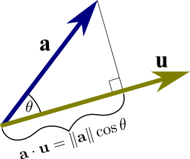

### 4.2.1 向量 - 创建

一般来说，采用函数`c()`即可完成向量的创建，只要在括号中输入每个向量元素就好啦！有同学要抗议了，这么做多费事，有没有快捷简单点的方法？**捷径在于规律**。

如果你知道你的向量是以什么规律排列，你就有可能找到专为它量身打造的函数。比如你想创建的向量是等差数列，就可以用到`seq`函数；如果你想创建从a到b的连续整数，使用`a:b`就可搞定；如果你想从一串数字中随机抽取几个数，使用`sample`函数就可完美实现；如果你再会玩点，用上字符串的粘贴功能函数`paste`, 你就可以把字符和数字有规律的组合起来（比如，当你想批量命名变量时），下面就是一些实现效果：

```r
vector(mode = "character", length = 3)
```

```
## [1] "" "" ""
```

```r
v <- c(0, 1, -2)
```

```r
typeof(v)
```

```
## [1] "double"
```

```r
class(v)
```

```
## [1] "numeric"
```

```r
length(v)
```

```
## [1] 3
```

```r
a <- 1:10
a
```

```
##  [1]  1  2  3  4  5  6  7  8  9 10
```

```r
b <- seq(1,10, by = 2)
b
```

```
## [1] 1 3 5 7 9
```

```r
c <- c('a', 'b', 'c')
c
```

```
## [1] "a" "b" "c"
```

```r
d <- sample(a, size = 20, replace = T)
d
```

```
##  [1]  8  8  3  2  1  8  8  1  7  4  7  2  4  3  5  5  6 10  8  6
```

```r
e <- paste("x_", 1:5, collapse = ",")
e
```

```
## [1] "x_ 1,x_ 2,x_ 3,x_ 4,x_ 5"
```

### 4.2.2 向量 - 类型转换

```r
as.character(v)
```

```
## [1] "0"  "1"  "-2"
```

```r
as.logical(v)
```

```
## [1] FALSE  TRUE  TRUE
```

```r
class(v)
```

```
## [1] "numeric"
```

```r
class(as.logical(v))
```

```
## [1] "logical"
```

### 4.2.3 向量 - 索引

```r
v[2]
```

```
## [1] 1
```

```r
v[c(2, 3)]
```

```
## [1]  1 -2
```

```r
v[2:3]
```

```
## [1]  1 -2
```

```r
v[-2]
```

```
## [1]  0 -2
```

```r
which(v==1)
```

```
## [1] 2
```

```r
v[which(v < 1)]
```

```
## [1]  0 -2
```

### 4.2.4 向量 - 元素命名

```r
names(v)
```

```r
names(v) <- c("Davide", "Linda", "Smale")
names(v)
```

```
## [1] "Davide" "Linda"  "Smale"
```

```r
v[c("Davide", "Linda")]
```

```
## Davide  Linda
##      0      1
```

### 4.2.5 向量 - 运算

```r
t <- c(2, 1, 3)
```

```r
names(v) <- c("Davide", "Linda", "Smale")
(v + t)/2
```

```
## Davide  Linda  Smale
##    1.0    1.0    0.5
```

```r
t > v
```

```
## Davide  Linda  Smale
##   TRUE  FALSE   TRUE
```

```r
summary(v)
```

```
##    Min. 1st Qu.  Median    Mean 3rd Qu.    Max.
## -2.0000 -1.0000  0.0000 -0.3333  0.5000  1.0000
```

### 4.2.6 向量 - 函数

| 命令 | 描述 |
| --- | --- |
| `sum(v)` | 对 `v`的所有元素求和 |
| `mean(v)` | 求 `v`的均值 |
| `median(v)` | 求 `v`的中位数 |
| `min(v), max(v)` | 求`v`的最值 |
| `sd(v), var(v)` | 求`v`的标准差和方差 |
| `length(v)` | `v`中的元素个数 |
| `pmax(v1, v2), pmin(v1, v2)` | 示例: `pmax(quiz1, quiz2)` 返回每个学生两次测验中的较高成绩 |
| `sort(v)` | 对`v`排序 |
| `order(v)` | 返回 `v`排序后的索引 |
| `unique(v)` | 对 `v`去重 |
| `summary(v)` | “五数”概述 |
| `any(v)` | 是否`v`中存在一个元素为TRUE |
| `all(v)` | 是否`v`中所有元素均为TRUE |
| `intersect` | 交集运算 |
| `union` | 并集运算 |
| `setdiff` | 差集运算 |

```r
f <- c(1,2,3,2,1,1,1,2,3,4,5,1,3,1,2,3,1)
x <- letters[f]
x
```

```
##  [1] "a" "b" "c" "b" "a" "a" "a" "b" "c" "d" "e" "a" "c" "a" "b" "c" "a"
```

```r
match(x, letters[1:5])
```

```
##  [1] 1 2 3 2 1 1 1 2 3 4 5 1 3 1 2 3 1
```

```r
match(x, letters[1:7])
```

```
##  [1] 1 2 3 2 1 1 1 2 3 4 5 1 3 1 2 3 1
```

```r
match(x, letters[1:3])
```

```
##  [1]  1  2  3  2  1  1  1  2  3 NA NA  1  3  1  2  3  1
```

### 4.2.7 向量-字符向量

字符这种变量类型不同于数值，它有很多独特的特征，有很多特别的小脾气需要些专用函数才能收好。先拿单独一个字符对象来说就有很多独特性，比如我们通常不太会对一个数值求它的长度，但对一个字符，我们很可能就需要了解它的长度，比如下面

```r
length("欢迎关注狗熊会")
```

```
## [1] 1
```

```r
nchar("欢迎关注狗熊会")
```

[output not shown]

```r
nchar("Welcome to follow the Clubear")
```

```
## [1] 29
```

既然有了长度，我们就可以对字符进行切分，提取出一个子字符串，这时候会使用到的函数是`substr`，具体用法是`substr(“char”, begin_position, end_position)`，比如下面的示例：

```r
substr("Welcome to follow the Clubear", 3,9)
```

```
## [1] "lcome t"
```

```r
paste(1:4)
```

```
## [1] "1" "2" "3" "4"
```

```r
paste(1:4, collapse = "")
```

```
## [1] "1234"
```

```r
paste(1:4, sep = "")
```

```
## [1] "1" "2" "3" "4"
```

```r
paste(1:4, collapse = ",")
```

```
## [1] "1,2,3,4"
```

```r
paste(1:4, sep = ",")
```

```
## [1] "1" "2" "3" "4"
```

```r
paste(letters[1:4], 1:4)
```

```
## [1] "a 1" "b 2" "c 3" "d 4"
```

```r
paste(letters[1:4], 1:4, collapse = "_")
```

```
## [1] "a 1_b 2_c 3_d 4"
```

```r
paste(letters[1:4], 1:4, sep = "_")
```

```
## [1] "a_1" "b_2" "c_3" "d_4"
```

```r
paste(letters[1:4], 1:4, collapse = "_",sep = "|")
```

```
## [1] "a|1_b|2_c|3_d|4"
```

```r
t <- c("狗熊会", "Clubear", "Social Science")
grep("Social", t)
```

```
## [1] 3
```

```r
# 求工资的均值
salary <- c("10w", "15w", "23w", "28w")
```

```r
mean(salary)
```

```
## [1] NA
```

- 提示使用`gsub`函数

## 4.3 Matrix

### 4.3.1 矩阵 - 创建

```r
M <- matrix(1:9, nrow = 3, ncol = 3)
print(M)
```

```
##      [,1] [,2] [,3]
## [1,]    1    4    7
## [2,]    2    5    8
## [3,]    3    6    9
```

```r
length(M)
```

```
## [1] 9
```

```r
dim(M)
```

```
## [1] 3 3
```

```r
cbind(1:3, 4:6)
```

```
##      [,1] [,2]
## [1,]    1    4
## [2,]    2    5
## [3,]    3    6
```

```r
rbind(1:3, 4:6)
```

```
##      [,1] [,2] [,3]
## [1,]    1    2    3
## [2,]    4    5    6
```

```r
attributes(M)
```

```
## $dim
## [1] 3 3
```

```r
I <- diag(1:4)
I
```

```
##      [,1] [,2] [,3] [,4]
## [1,]    1    0    0    0
## [2,]    0    2    0    0
## [3,]    0    0    3    0
## [4,]    0    0    0    4
```

```r
vec <- 1:9
vec
```

```
## [1] 1 2 3 4 5 6 7 8 9
```

```r
attributes(vec)
```

```r
dim(vec) <- c(3, 3)
```

```r
vec
```

```
##      [,1] [,2] [,3]
## [1,]    1    4    7
## [2,]    2    5    8
## [3,]    3    6    9
```

### 4.3.2 矩阵 - 索引

```r
M[2,3]
```

```
## [1] 8
```

```r
M[1, ]
```

```
## [1] 1 4 7
```

```r
M[, 2]
```

```
## [1] 4 5 6
```

### 4.3.3 矩阵 - 运算

```r
Q <- matrix(rep(10, 9), 3, 3)
```

```r
M * Q
```

```
##      [,1] [,2] [,3]
## [1,]   10   40   70
## [2,]   20   50   80
## [3,]   30   60   90
```

```r
M %*% Q
```

```
##      [,1] [,2] [,3]
## [1,]  120  120  120
## [2,]  150  150  150
## [3,]  180  180  180
```

### 4.3.4 矩阵 - 函数

```r
colMeans(M)
```

```
## [1] 2 5 8
```

```r
colSums(M)
```

```
## [1]  6 15 24
```

```r
colnames(M)
```

```r
rownames(M)
```

### 4.3.5 稀疏矩阵

```r
# install.packages(Matrix)
library(Matrix)
vectors <- c(1:4, rep(0,4), 5,0,0,9)
m <- matrix(vectors, nrow = 4)
print(m)
```

```
##      [,1] [,2] [,3]
## [1,]    1    0    5
## [2,]    2    0    0
## [3,]    3    0    0
## [4,]    4    0    9
```

```r
sm <- Matrix(vectors,nrow = 4, sparse = TRUE)
print(sm)
```

```
## 4 x 3 sparse Matrix of class "dgCMatrix"
##
## [1,] 1 . 5
## [2,] 2 . .
## [3,] 3 . .
## [4,] 4 . 9
```

```r
summary(sm)
```

```
## 4 x 3 sparse Matrix of class "dgCMatrix", with 6 entries
##   i j x
## 1 1 1 1
## 2 2 1 2
## 3 3 1 3
## 4 4 1 4
## 5 1 3 5
## 6 4 3 9
```

```r
sm <- spMatrix(nrow = 10,ncol = 20,i = 1:7,j = 1:7,x = 7*(1:7))
print(sm)
```

```
## 10 x 20 sparse Matrix of class "dgTMatrix"
##
##  [1,] 7  .  .  .  .  .  . . . . . . . . . . . . . .
##  [2,] . 14  .  .  .  .  . . . . . . . . . . . . . .
##  [3,] .  . 21  .  .  .  . . . . . . . . . . . . . .
##  [4,] .  .  . 28  .  .  . . . . . . . . . . . . . .
##  [5,] .  .  .  . 35  .  . . . . . . . . . . . . . .
##  [6,] .  .  .  .  . 42  . . . . . . . . . . . . . .
##  [7,] .  .  .  .  .  . 49 . . . . . . . . . . . . .
##  [8,] .  .  .  .  .  .  . . . . . . . . . . . . . .
##  [9,] .  .  .  .  .  .  . . . . . . . . . . . . . .
## [10,] .  .  .  .  .  .  . . . . . . . . . . . . . .
```

```r
summary(sm)
```

```
## 10 x 20 sparse Matrix of class "dgTMatrix", with 7 entries
##   i j  x
## 1 1 1  7
## 2 2 2 14
## 3 3 3 21
## 4 4 4 28
## 5 5 5 35
## 6 6 6 42
## 7 7 7 49
```

## 4.4 Data Frame

数据框是我们最常见的数据结构，一般来讲，我们从csv或txt文件读入时就会自动存储为数据框对象。该结构同样拥有表格状，但与矩阵所不同的是，矩阵只可以存储一种数据类型（比如，数值与字符型数据不能同时存在于矩阵中）。而实际中，我们看到的数据表格往往有很多类型，例如：字符、日期、数值包含在不同列中。想要在R中读入并表示这种数据，数据框就可以派上用场了。当然需要特别注意的是：**数据框的每一列都必须还是同一种数据类型**。如果不符合规定，R会在一定范围内强制转化数据类型，比如你输入的一列里既有文本又有数值，它会把该列强制转化成全是文本格式，这点大家要特别留意。

### 4.4.1 数据框 - 创建

```r
nutrition <- data.frame(fruit = c("apples", "pears", "bananas"), calories = c(52, 57, 92))
```

```r
head(nutrition, 3)
```

```
##     fruit calories
## 1  apples       52
## 2   pears       57
## 3 bananas       92
```

```r
ncol(nutrition)
```

```
## [1] 2
```

```r
nrow(nutrition)
```

```
## [1] 3
```

```r
cbind(nutrition, nutrition)
```

```
##     fruit calories   fruit calories
## 1  apples       52  apples       52
## 2   pears       57   pears       57
## 3 bananas       92 bananas       92
```

```r
rbind(nutrition, nutrition)
```

```
##     fruit calories
## 1  apples       52
## 2   pears       57
## 3 bananas       92
## 4  apples       52
## 5   pears       57
## 6 bananas       92
```

### 4.4.2 数据框 - 属性

```r
names(nutrition)[1] <- "type"
```

```r
attributes(nutrition)
```

```
## $names
## [1] "type"     "calories"
##
## $row.names
## [1] 1 2 3
##
## $class
## [1] "data.frame"
```

```r
colnames(nutrition)
```

```
## [1] "type"     "calories"
```

### 4.4.3 数据框 - 概览

```r
str(nutrition)
```

```
## 'data.frame':    3 obs. of  2 variables:
##  $ type    : Factor w/ 3 levels "apples","bananas",..: 1 3 2
##  $ calories: num  52 57 92
```

```r
summary(nutrition)
```

```
##       type      calories
##  apples :1   Min.   :52.0
##  bananas:1   1st Qu.:54.5
##  pears  :1   Median :57.0
##              Mean   :67.0
##              3rd Qu.:74.5
##              Max.   :92.0
```

### 4.4.4 数据框 - 索引

```r
nutrition[which(nutrition$type == "apples"), ]
```

```
##     type calories
## 1 apples       52
```

```r
nutrition$calories # 返回结果为向量
```

```
## [1] 52 57 92
```

```r
nutrition[["calories"]] # 返回结果为向量
```

```
## [1] 52 57 92
```

```r
nutrition["calories"] # 返回结果为数据框
```

```
##   calories
## 1       52
## 2       57
## 3       92
```

### 4.4.5 数据框 - 函数

```r
calorie <- nutrition[["calories"]]
```

```r
max(calorie)
```

```
## [1] 92
```

选出calories大于80的水果

```
##      type
## 3 bananas
```

- 提示使用函数`subset`

```r
row.names(nutrition)
```

```
## [1] "1" "2" "3"
```

```r
rownames(nutrition)
```

```
## [1] "1" "2" "3"
```

## 4.5 List

### 4.5.1 列表 - 创建

```r
list(
  c("john", "dave", "linda", "kino"),
  c(183, 168, 177, 167),
  c("M", "F", "M"))
```

```
## [[1]]
## [1] "john"  "dave"  "linda" "kino"
##
## [[2]]
## [1] 183 168 177 167
##
## [[3]]
## [1] "M" "F" "M"
```

```r
L <- list(
  name = c("john", "dave", "linda", "kino"),
  height = c(183, 168, 177, 167),
  gender = c("M", "F", "M"))

L
```

```
## $name
## [1] "john"  "dave"  "linda" "kino"
##
## $height
## [1] 183 168 177 167
##
## $gender
## [1] "M" "F" "M"
```

```r
str(L)
```

```
## List of 3
##  $ name  : chr [1:4] "john" "dave" "linda" "kino"
##  $ height: num [1:4] 183 168 177 167
##  $ gender: chr [1:3] "M" "F" "M"
```

```r
Doraemon.bag <- list(
  char = "K",
  num = c(2, 2, 6),
  mat = matrix(6, 2, 2),
  df = data.frame(A = 1:3, I = 4:6),
  list = list(D = 1, M = 9)
)

str(Doraemon.bag)
```

```
## List of 5
##  $ char: chr "K"
##  $ num : num [1:3] 2 2 6
##  $ mat : num [1:2, 1:2] 6 6 6 6
##  $ df  :'data.frame':    3 obs. of  2 variables:
##   ..$ A: int [1:3] 1 2 3
##   ..$ I: int [1:3] 4 5 6
##  $ list:List of 2
##   ..$ D: num 1
##   ..$ M: num 9
```

### 4.5.2 列表 - 索引

```r
L <- list(
  name = c("john", "dave", "linda", "kino"),
  height = c(183, 168, 177, 167),
  gender = c("M", "F", "M"))
L$name
```

```
## [1] "john"  "dave"  "linda" "kino"
```

```r
L[["name"]]
```

```
## [1] "john"  "dave"  "linda" "kino"
```

```r
L["name"]
```

```
## $name
## [1] "john"  "dave"  "linda" "kino"
```

```r
c(is.vector(L$name), is.vector(L[["name"]]),
  is.list(L["name"]))
```

```
## [1] TRUE TRUE TRUE
```

## 4.6 Factor

### 4.6.1 因子 - 创建与属性

```r
f <- factor(c("yes", "yes", "no", "no", "yes"))

f
```

```
## [1] yes yes no  no  yes
## Levels: no yes
```

```r
attributes(f)
```

```
## $levels
## [1] "no"  "yes"
##
## $class
## [1] "factor"
```

```r
f <- factor(
  c("yes", "yes", "no", "no", "yes"),
  levels = c("yes", "no"))

f
```

```
## [1] yes yes no  no  yes
## Levels: yes no
```

```r
attr(f, "levels") <- c("y", "n")

unclass(f)
```

```
## [1] 1 1 2 2 1
## attr(,"levels")
## [1] "y" "n"
```

### 4.6.2 因子 - cut

```r
age <- sample(21:99, size = 50, replace = T)
age
```

```
##  [1] 66 91 75 50 90 66 52 85 90 72 35 66 50 68 91 55 74 40 21 64 37 45 53
## [24] 96 26 66 24 57 27 64 40 29 99 60 85 97 32 33 76 53 65 30 63 80 27 54
## [47] 82 30 58 44
```

```r
age_label <- cut(age, breaks = c(20,45,75,100), labels = c("yong","middle","old"))
age_label
```

```
##  [1] middle old    middle middle old    middle middle old    old    middle
## [11] yong   middle middle middle old    middle middle yong   yong   middle
## [21] yong   yong   middle old    yong   middle yong   middle yong   middle
## [31] yong   yong   old    middle old    old    yong   yong   old    middle
## [41] middle yong   middle old    yong   middle old    yong   middle yong
## Levels: yong middle old
```

## 4.7 Date

```r
# 想知道今天日期
today <- Sys.Date()
# ISO 8601的标准yyyy-mm-dd
print(today)
```

```
## [1] "2018-07-10"
```

```r
typeof(today)
```

```
## [1] "double"
```

```r
class(today)
```

```
## [1] "Date"
```

```r
# 字符串转化为时间格式
secondDay <- as.Date("2018-07-10")
print(secondDay)
```

```
## [1] "2018-07-10"
```

```r
# 如果我们收集的数据里面的时间格式是07|10|2018如何处理？
thirdDay <- c("07|11|2018")
class(thirdDay)
```

```
## [1] "character"
```

```r
print(thirdDay)
```

```
## [1] "07|11|2018"
```

```r
thirdDay <- as.Date(thirdDay, format = "%m|%d|%y")
class(thirdDay)
```

```
## [1] "Date"
```

```r
print(thirdDay)
```

```
## [1] "2020-07-11"
```

```r
#如果我们收集的数据里面的时间格式是07|10|2018如何处理?
```

| `format`参数 | 描述 |
| --- | --- |
| `%b` | 缩写月份Jan |
| `%B` | 完整月份名称 |
| `%d` | 两位数的日期 |
| `%m` | 两位数的月份 |
| `%y` | 没有世纪的年份 |
| `%Y` | 有世纪的年份 |

```r
today <- ISOdate(year = 2018,month = 07,day = 10)
print(today)
```

```
## [1] "2018-07-10 12:00:00 GMT"
```

```r
class(today)
```

```
## [1] "POSIXct" "POSIXt"
```

```r
today <- as.Date(today)
class(today)
```

```
## [1] "Date"
```

```r
y <- 2015:2018
m <- 5:8
d <- 5:8
ISOdate(y,m,d)
```

```
## [1] "2015-05-05 12:00:00 GMT" "2016-06-06 12:00:00 GMT"
## [3] "2017-07-07 12:00:00 GMT" "2018-08-08 12:00:00 GMT"
```

```r
# ISOdatetime可以扩展到“时，分，秒”
```

```r
#时间是相对概念，所以R中选取的标准时间是1970-01-01
as.integer(today)
```

```
## [1] 17722
```

```r
julian(today)
```

```
## [1] 17722
## attr(,"origin")
## [1] "1970-01-01"
```

```r
as.integer(as.Date("1970-01-02"))
```

```
## [1] 1
```

```r
# 提取日期一部分方法：把Date的对象转化为POSIXlt的对象。它是一个日期各个组成元素的一个列表。

today_list <- as.POSIXlt(today)
print(today_list)
```

```
## [1] "2018-07-10 UTC"
```

```r
class(today_list)
```

```
## [1] "POSIXlt" "POSIXt"
```

```r
today_list$mday
```

```
## [1] 10
```

```r
today_list$mon # January = 0
```

```
## [1] 6
```

```r
today_list$year
```

```
## [1] 118
```

```r
today_list$year + 1900
```

```
## [1] 2018
```

[output not shown]

```r
# 创建日期序列
f <- as.Date("2018-07-01")
t <- as.Date("2018-07-10")
seq(from = f, to = t, by = 1)
```

```
##  [1] "2018-07-01" "2018-07-02" "2018-07-03" "2018-07-04" "2018-07-05"
##  [6] "2018-07-06" "2018-07-07" "2018-07-08" "2018-07-09" "2018-07-10"
```

```r
# 日期的相关计算
#做差
#求任意两个日期距离的天数
begin=as.Date("2016-03-04")
end=as.Date("2016-05-08")
(during=end-begin)
```

```
## Time difference of 65 days
```

```r
#求任意两个日期距离的周数和小时数
difftime(end,begin,units = "weeks")
```

```
## Time difference of 9.285714 weeks
```

```r
difftime(end,begin,units = "hours")
```

```
## Time difference of 1560 hours
```

以上介绍的都是base基础包里自带的函数，下面要为大家介绍一款专门高效处理时间数据各种疑难杂症的包`lubridate`. 这是一个民间口碑极佳的数据预处理包包，曾屡次获得“能大幅提高数据预处理效率的精品”，“最让人感觉相见恨晚的包包”等美誉，足见它的群众基础多么深厚！lubridate包主要有两类函数，一类是处理时点数据，另一类是处理时段数据，不仅功能强大，而且相应函数也很直观易懂，比如把字符转化成时间类型，根本不需要输入匹配的format，比如提取时间数据细节，也只是一个小函数即可完美搞定，不附带任何参数。

```
## [1] "2009-01-01" "2009-01-02" "2009-01-03" "2009-01-04" "2009-01-05"
## [6] "2009-01-06" "2009-01-07"
```

```
## [1] 20
```

```
## [1] 6
```

```
## [1] 1
```

```
## [1] 30
```

## 4.8 Missing Value

- NaN
- NA

```r
q <- c(1, NaN, NA, 4)
```

```r
class(q)
```

```
## [1] "numeric"
```

```r
is.nan(q)
```

```
## [1] FALSE  TRUE FALSE FALSE
```

```r
is.na(q)
```

```
## [1] FALSE  TRUE  TRUE FALSE
```

```r
mean(q)
```

```
## [1] NaN
```

```r
mean(q, na.rm = T)
```

```
## [1] 2.5
```

```r
is.na(NA)
is.na(NaN)
is.nan(NaN)
is.na(NA)
```

# 5 R中的数据读写

- 读取csv

```r
data <- read.csv("./data/data.csv", header = TRUE)

data <- read.table("./data/data.txt", header = TRUE)
```

- 写入csv

```r
write.table(data, file = "./data/dataout.txt")
write.csv(data, file = "./data/dataout.csv")
```

# 6 R中控制流

- **if, else**
- **for** and something new
- while
- repeat
- break
- next

## 6.1 if, else

```r
s <- 1:5
ifelse(s > 3, yes = "Good", no = "Fair")
```

```
## [1] "Fair" "Fair" "Fair" "Good" "Good"
```

```r
a <- 1

if(a > 2){
  b <- 1
}else{
  b <- 0
}
```

```r
b
```

```
## [1] 0
```

```r
a <- -1

if(a > 2){
  b <- 1
}else if(a < 0){
  b <- 1
}else{
  b <- 0
}
```

```r
b
```

```
## [1] 1
```

## 6.2 for

```r
for(i in 1:3){
  print(i)
}
```

```
## [1] 1
## [1] 2
## [1] 3
```

```r
M <- matrix(1:2, 2, 3)
```

```r
M
```

```
##      [,1] [,2] [,3]
## [1,]    1    1    1
## [2,]    2    2    2
```

- 对列求和

```r
numeric(3)
```

```
## [1] 0 0 0
```

```r
col.sum <- numeric(ncol(M))
for(j in 1:ncol(M)){
  for(i in 1:nrow(M)){
    col.sum[j] <- col.sum[j] + M[i, j]
  }
}
```

```r
col.sum
```

```
## [1] 3 3 3
```

- 对列求和

```r
M
```

```
##      [,1] [,2] [,3]
## [1,]    1    1    1
## [2,]    2    2    2
```

- **向量化运算**

```r
col.sum
```

```
## [1] 3 3 3
```

## 6.3 while

```r
i <- 0
while(i < 3){
  print(i)
  i <- i + 1
}
```

```
## [1] 0
## [1] 1
## [1] 2
```

[figure not shown]

## 6.4 repeat and break

```r
i <- 0
repeat{
  print(i)
  ifelse(i > 1, yes = break, no = i <- i + 1)
}
```

```
## [1] 0
## [1] 1
## [1] 2
```

## 6.5 next

- next

```r
for(i in 1:10){
  if(i <= 7){
    next
  }
  print(i)
  i <- i + 1
}
```

```
## [1] 8
## [1] 9
## [1] 10
```

## 6.6 Apply系列

```r
print(M)
```

```
##      [,1] [,2] [,3]
## [1,]    1    1    1
## [2,]    2    2    2
```

```r
apply(M, 2, sum)
```

```
## [1] 3 3 3
```

```r
apply(M, 1, sum)
```

```
## [1] 3 6
```

### 6.6.1 lapply and sapply

```r
L <- list(
  a = matrix(1:3, 1),
  b = data.frame(
    char = c("A", "B"),
    logic = c(T, F)),
  c = list(
    1:3,
    "T",
    matrix(1:6, 2, 3)))
L
```

```
## $a
##      [,1] [,2] [,3]
## [1,]    1    2    3
##
## $b
##   char logic
## 1    A  TRUE
## 2    B FALSE
##
## $c
## $c[[1]]
## [1] 1 2 3
##
## $c[[2]]
## [1] "T"
##
## $c[[3]]
##      [,1] [,2] [,3]
## [1,]    1    3    5
## [2,]    2    4    6
```

```r
lapply(L, class)
```

```
## $a
## [1] "matrix"
##
## $b
## [1] "data.frame"
##
## $c
## [1] "list"
```

```r
sapply(L, class)
```

```
##            a            b            c
##     "matrix" "data.frame"       "list"
```

### 6.6.2 mapply

```
## [[1]]
## [1] 1 1 1 1 1 1
##
## [[2]]
## [1] 2 2 2 2 2
##
## [[3]]
## [1] 3 3 3 3
##
## [[4]]
## [1] 4 4 4
##
## [[5]]
## [1] 5 5
##
## [[6]]
## [1] 6
```

[figure not shown]

```r
mapply(rep, 1:6, 6:1)
```

### 6.6.3 tapply

```r
set.seed(6)
n <- 9
bike <- data.frame(
  orgn = sample(c("SE", "S", "N"), n, replace = T),
  dest = sample(c("SE", "S", "N"), n, replace = T),
  flux = round(rnorm(n, 18)))
```

[figure not shown]

```r
bike
```

```
##   orgn dest flux
## 1    S   SE   17
## 2    N    S   20
## 3   SE    N   17
## 4    S   SE   19
## 5    N   SE   18
## 6    N    N   17
## 7    N   SE   18
## 8    N    S   20
## 9    S    N   17
```

```r
tapply(X = bike$flux, INDEX = bike$orgn, FUN = sum)
```

```
##  N  S SE
## 93 53 17
```

```
##
##      N S SE
##   N  1 2  2
##   S  1 0  2
##   SE 1 0  0
```

```
##     dest
## orgn  N  S SE
##   N  17 20 18
##   S  17 NA 18
##   SE 17 NA NA
```

### 6.6.4 小结：apply函数族

| 命令 | 描述 |
| --- | --- |
| `apply(X, MARGIN, FUN)` | 通过对一个数组或矩阵`X`的指定`MARGIN`应用`FUN`来得到一个向量/数组/列表 |
| `lapply(X, FUN)` | 通过对一个列表`X`的元素应用`FUN` 来得到一个列表 |
| `sapply(X, FUN)` | `lapply`的简化版本返回一个向量/数组而不是列表 |
| `mapply(FUN)` | `lapply`的多变元版本 |
| `tapply(X, INDEX, FUN)` | 通过对`INDEX`制定的因子组合应用`FUN`函数来得到一个表格 |

# 7 R中的函数

- 定义
- 参数
- 封装

## 7.1 Definition

```r
rsummary <- function(x) {
  return(
    list(
    mean = mean(x),
    sd = sd(x),
    quantiles = quantile(x)))
}
```

```r
x <- rnorm(100, mean = 6, sd = 1)
```

```r
rsummary(x)
```

```
## $mean
## [1] 5.928524
##
## $sd
## [1] 0.990941
##
## $quantiles
##       0%      25%      50%      75%     100%
## 4.047651 5.268584 5.818003 6.522913 8.608098
```

```r
calGrade <- function(x, base = 59) {
  s <- x + base
  if(s >= 90) {
    grade <- "A"
  } else if(s >= 80) {
    grade <- "B"
  } else if(s >= 70) {
    grade <- "C"
  } else if(x >= 60){
    grade <- "D"
  }else{
    grade <- "Failed"
  }
  grade
}

scores <- c(40, 20, 27, 31, 0, 0)

calGrade(scores)
```

```
## [1] "A"
```

```r
lapply(scores, calGrade)
```

```
## [[1]]
## [1] "A"
##
## [[2]]
## [1] "C"
##
## [[3]]
## [1] "B"
##
## [[4]]
## [1] "A"
##
## [[5]]
## [1] "Failed"
##
## [[6]]
## [1] "Failed"
```

- return

```r
square <- function(x) {
  return(x^2)
}

square(11)
```

```
## [1] 121
```

```r
square <- function(x) {
  x^2
}

square(11)
```

```
## [1] 121
```

## 7.2 Parameter

- `formals`

```r
formals(calGrade)
```

```
## $x
##
##
## $base
## [1] 59
```

```r
formals(plot)
```

- 可以缺失，可能有缺省值
- 参数匹配

```r
(M <- matrix(1:6, nrow = 2)) # 精确匹配
```

```
##      [,1] [,2] [,3]
## [1,]    1    3    5
## [2,]    2    4    6
```

```r
(M <- matrix(1:6, nr = 2)) # 部分匹配
```

```
##      [,1] [,2] [,3]
## [1,]    1    3    5
## [2,]    2    4    6
```

```r
(M <- matrix(1:6, 2)) # 位置匹配
```

```
##      [,1] [,2] [,3]
## [1,]    1    3    5
## [2,]    2    4    6
```

> `quantile(x, probs = seq(0, 1, 0.25), ...)`  
> `apply(X, MARGIN, FUN, ...)`

```r
set.seed(1)
(x <- matrix(rnorm(12), 3))
```

```
##            [,1]       [,2]      [,3]       [,4]
## [1,] -0.6264538  1.5952808 0.4874291 -0.3053884
## [2,]  0.1836433  0.3295078 0.7383247  1.5117812
## [3,] -0.8356286 -0.8204684 0.5757814  0.3898432
```

```r
apply(x, 2, quantile)  # matrix
```

```
##            [,1]       [,2]      [,3]        [,4]
## 0%   -0.8356286 -0.8204684 0.4874291 -0.30538839
## 25%  -0.7310412 -0.2454803 0.5316052  0.04222742
## 50%  -0.6264538  0.3295078 0.5757814  0.38984324
## 75%  -0.2214052  0.9623943 0.6570530  0.95081220
## 100%  0.1836433  1.5952808 0.7383247  1.51178117
```

> `quantile(x, probs = seq(0, 1, 0.25), ...)`  
> `apply(X, MARGIN, FUN, ...)`

```r
set.seed(1)
(x <- matrix(rnorm(12), 3))
```

```
##            [,1]       [,2]      [,3]       [,4]
## [1,] -0.6264538  1.5952808 0.4874291 -0.3053884
## [2,]  0.1836433  0.3295078 0.7383247  1.5117812
## [3,] -0.8356286 -0.8204684 0.5757814  0.3898432
```

```r
apply(x, 2, quantile, probs = c(.25, .75))
```

```
##           [,1]       [,2]      [,3]       [,4]
## 25% -0.7310412 -0.2454803 0.5316052 0.04222742
## 75% -0.2214052  0.9623943 0.6570530 0.95081220
```

```r
str(paste)
```

```
## function (..., sep = " ", collapse = NULL)
```

- **GOOD**

```r
paste("Hi", " There", sep = "!")
```

```
## [1] "Hi! There"
```

- **BAD**

```r
paste("Hi", " There", se = "!")
```

```
## [1] "Hi  There !"
```

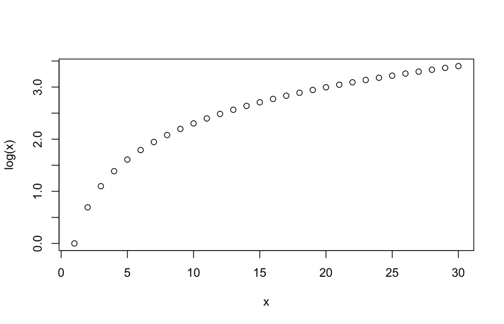

```r
x <- 1:30
plot(x, log(x))
```

- 自定义函数

```r
my.plot <-
  function(x, y, type = "l", ...){
     plot(x, y, type = type, ...)
}
```

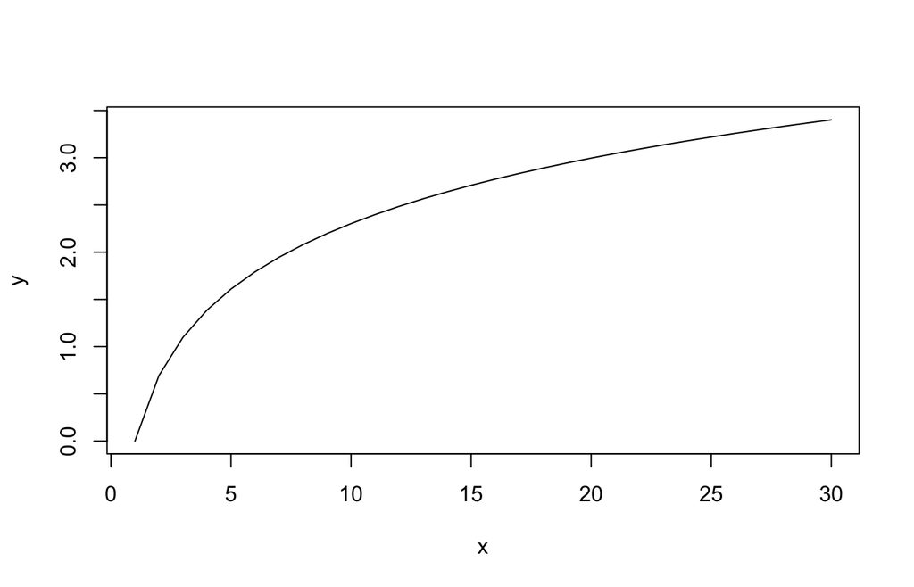

```r
my.plot(x, log(x))
```

## 7.3 Encapsulation

- Obsessive Compulsive Disorder, OCD

[figure not shown]

- 主文件调用函数文件

```r
source("./fn/MyPlotEncap.R")
my.plot.encap(x, log(x))
```

# 8 作业

第一部分：`swirl`包是一款专门的进行R语言课后练习的包，你可以按照包的提示去一点点学习R语言。本门课的作业部分，会有部分内容的作业是由这个包来完成。这个包的详细介绍请[戳这里](http://swirlstats.com/)。整个包的代码库请[戳这里](https://github.com/swirldev/swirl_courses)。请按照下面操作，完成本作业。

[figure not shown]

```r
knitr::include_graphics('fig/swirl.png')
```

首先，安装`swirl`包如下：

```r
install.packages("swirl")
```

其次，启动`swirl`包如下：

```r
# 载入swirl
library("swirl")

# 启动swirl
swirl()
```

这里会出现如下界面：

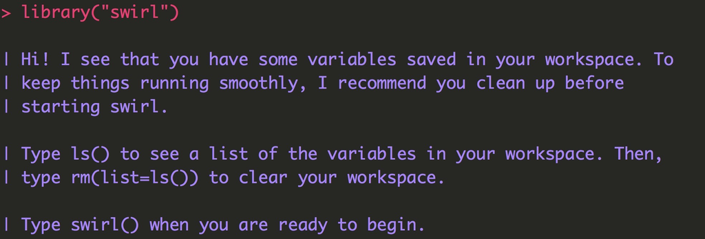

输入`swirl()`后，会继续出现

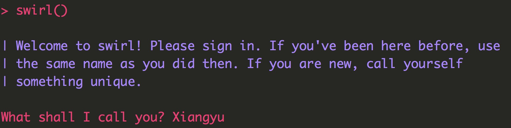

输入你自己的名字，然后会进入课程选择

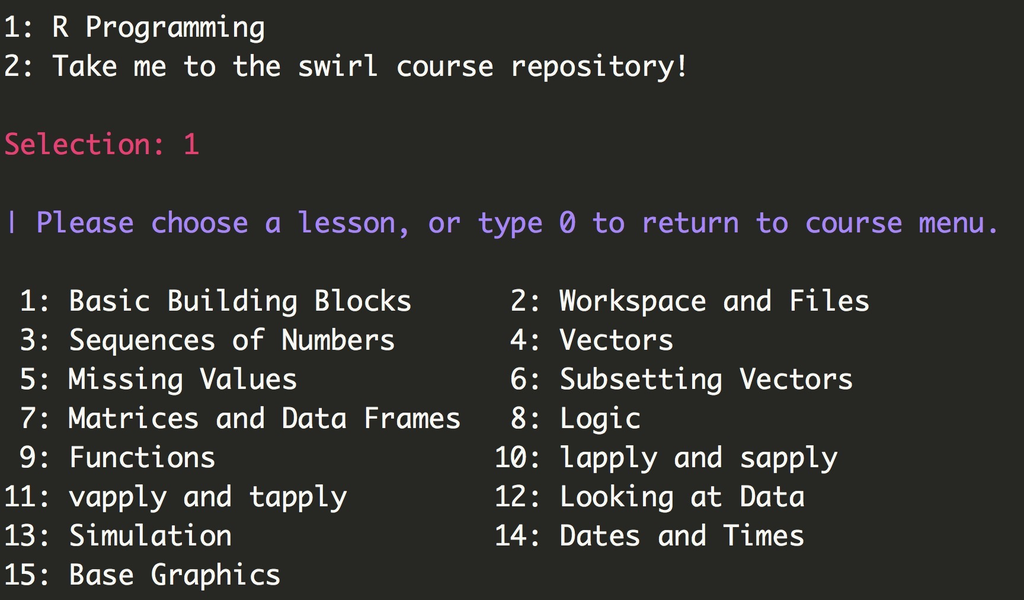

好了，第二天作业，大家能完成1-5.

第二部分：

- 观看**狗熊会**视频微课中的**R语言入门**视频，学习如何导入数据到R。
- 下载Speed Dating的数据，数据描述与文章
- 建立一个R Markdown文档
- 读入Speed Dating的数据
- 修改gender为因子类型
- 计算试验男女比例
- 计算男性在约会前对于自己心仪对象的各个维度评分的均值（attr1_1“,”sinc1_1“,”intel1_1“,”fun1_1“,”amb1_1“,”shar1_1“）
- 计算女性约会前对于自己心仪对象的各个维度评分均值(attr1_1“,”sinc1_1“,”intel1_1“,”fun1_1“,”amb1_1“,”shar1_1)
- 你有什么结论吗？
- 思考还有什么问题可以研究？